# Supplementary Troponin Analysis

Improving risk stratification for patients with type 2 myocardial infarction

The objective of this analysis is to construct a linear regression model, which permits to predict log troponin I from log tropinin T. Such model, will permit to employ the proposed T-2 risk score when we only have access to troponin T.

# 1 Data pre-processing

The data here used corresponds to patients with suspected acute coronary syndrome that were recruited from the Emergency Department of the Royal Infirmary of Edinburgh, a tertiary care hospital in Scotland, between 1 June 2013 and 31 March 2017 into a substudy of the HighSTEACS trial. All patients in whom the attending clinician requested cardiac troponin for suspected acute coronary syndrome were eligible. We did not enrol patients with ST-segment elevation myocardial infarction, those unable to provide consent or those from outside our region to ensure complete follow-up. Blood samples were obtained at presentation and at 6–12 hours as part of routine clinical care, with surplus serum or lithium-heparin plasma samples collected. Patients provided written informed consent for additional sampling at 1 or 3 hours. Samples were centrifuged, aliquoted and stored at −80°C for batch processing.

The dataset contains two readings, one of troponin I and one of troponin T, for 1869 patients. In addition, the dataset contains an adjudication code, where:

- adj = 1 corresponds to Type 1 Myocardial infarction
- adj = 2 corresponds to Type 2 Myocardial infarction
- adj = 3 corresponds to Myocardial injury
- adj = 9 corresponds to NA
- adj = NA corresponds to No injury

We load the dataset and make the above adjudication codes explicit:

```r
library(readr)

substudy <-  as.data.frame(read_csv("~/Documents/Postdoc/DEMAND/highsteacs_substudy_troponin.csv"))

str(substudy)
```

```
## 'data.frame':    1869 obs. of  6 variables:
##  $ substudyid : num  1 2 3 5 6 7 8 9 10 11 ...
##  $ tni1_result: num  11508 3 5 3 8 ...
##  $ tni2_result: num  15733 4 5 3 12 ...
##  $ tnt1_result: num  712 4 17 7 6 11 4.99 66 12 20 ...
##  $ tnt2_result: num  NA 6 17 6 7 11 4.99 62 14 25 ...
##  $ adj        : num  1 NA NA NA NA NA NA 2 NA 1 ...
```

```r
substudy$adj[substudy$adj == 1] <- "Type 1 MI"
substudy$adj[substudy$adj == 2] <- "Type 2 MI"
substudy$adj[substudy$adj == 3] <- "Myocardial injury"
substudy$adj[substudy$adj == 9] <- NA
substudy$adj[is.na(substudy$adj)==TRUE] <- "No injury"
```

Because our aim is to model the relationship between tropinin I and tropinin T. Below, we re-arrange the data by stacking the two available tropinin readings. In addition, we remove rows of the stacked dataset where at leat one of the troponin reading were unvailable.

```r
stacked_data <- data.frame(cbind( tni = c(substudy$tni1_result, substudy$tni2_result),
                               tnt = c(substudy$tnt1_result, substudy$tnt2_result)),
                               adj = c(substudy$adj, substudy$adj))

#remove NAs
NA.I <- which(is.na(stacked_data$tni)==TRUE)
NA.T <- which(is.na(stacked_data$tnt)==TRUE)
stacked_data <- stacked_data[-c(unique(c(NA.I, NA.T))),]
row.names(stacked_data) <- NULL

#Number of available readings
nrow(stacked_data)
```

```
## [1] 3559
```

We further remove any troponin readings above and below the limit of detection of the assays employed (“ARCHITECT Stat High Sensitivity Troponin-I”)

- Lower limit of detection for troponin I is 3.5 ng/L and for troponin T 6.0 ng/L.
- Upper limit of detection for troponin I is 5,000 ng/L and for troponin T 10,000 ng/L.

```r
below_limit <- unique(c(which(stacked_data$tni <= 3.5), which(stacked_data$tnt <= 6)))
above_limit <- unique(c(which(stacked_data$tni >= 5000), which(stacked_data$tnt >= 10000)))

data_LOD <- stacked_data[-c(below_limit, above_limit),]
row.names(data_LOD) <- NULL
nrow(data_LOD)
```

```
## [1] 1327
```

Furthermore, as our objective is to model the relationship between troponin I and T in populations with MI, we remove readings corresponding to those subjects that have an adjudicated diagnose of no injury.

```r
data_LOD_subset <- data_LOD[-which(data_LOD$adj == "No injury"),]
row.names(data_LOD_subset) <- NULL

#Number of available troponin readings
nrow(data_LOD_subset)
```

```
## [1] 619
```

Finally, we compute the logarithm of both troponin I and T and produce a scatter plot of the data:

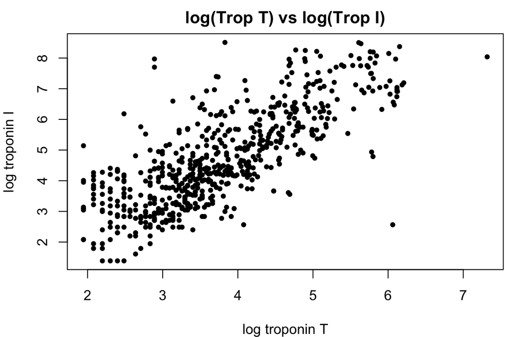

```r
data_LOD_subset$log.TropI <- log(data_LOD_subset$tni)
data_LOD_subset$log.TropT <- log(data_LOD_subset$tnt)

par(mar = c(4, 4, 2, .1))
plot(data_LOD_subset$log.TropT, data_LOD_subset$log.TropI,
     pch = 20,
     main = "log(Trop T) vs log(Trop I)",
     xlab = "log troponin T", ylab = "log troponin I")
```

# 2 Model fitting

We fit a linear regression model:

```r
trop.fit <- lm( log.TropI ~ log.TropT, data = data_LOD_subset)
summary(trop.fit)
```

```
##
## Call:
## lm(formula = log.TropI ~ log.TropT, data = data_LOD_subset)
##
## Residuals:
##     Min      1Q  Median      3Q     Max
## -4.8513 -0.6859 -0.1272  0.6591  4.2974
##
## Coefficients:
##             Estimate Std. Error t value Pr(>|t|)
## (Intercept)   0.2612     0.1543   1.692   0.0911 .
## log.TropT     1.1804     0.0396  29.807   <2e-16 ***
## ---
## Signif. codes:  0 '***' 0.001 '**' 0.01 '*' 0.05 '.' 0.1 ' ' 1
##
## Residual standard error: 0.9923 on 617 degrees of freedom
## Multiple R-squared:  0.5902, Adjusted R-squared:  0.5895
## F-statistic: 888.5 on 1 and 617 DF,  p-value: < 2.2e-16
```

And produce residuals plots:

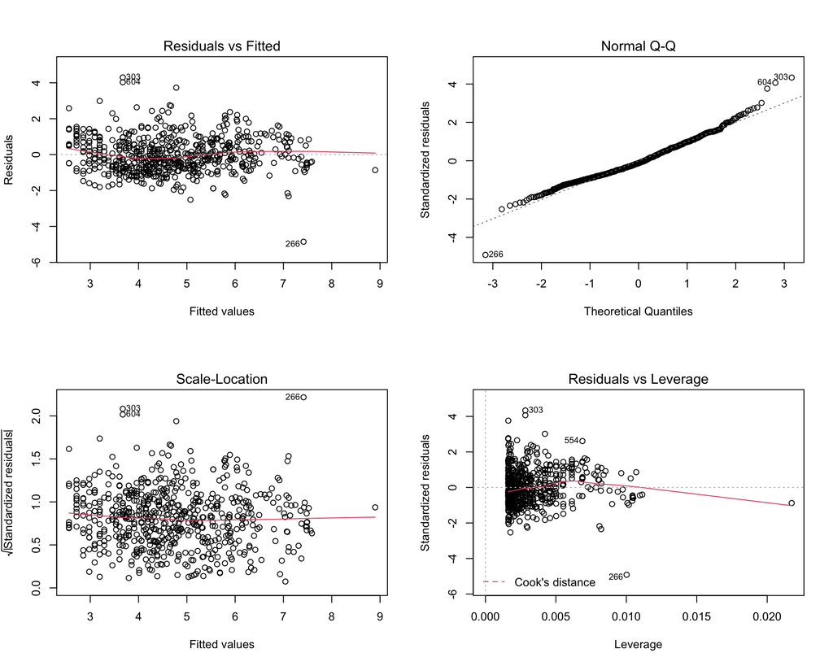

```r
par(mfrow=c(2,2))
plot(trop.fit)
```

From the plots above, we remove all strong outliers. In addition, we also remove one observation with an extremely high value in troponin T and one with an extremely high value in tropinin I, which are not inline with the overall trend in the data. The removed observations ar shown below:

```r
data_LOD_subset[c(303,604,266,554,444,110,422,
                  which(data_LOD_subset$log.TropT == max(data_LOD_subset$log.TropT)),
                  which(data_LOD_subset$log.TropI == max(data_LOD_subset$log.TropI))),]
```

```
##      tni  tnt               adj log.TropI log.TropT
## 303 2894   18 Myocardial injury  7.970395  2.890372
## 604 2213   18 Myocardial injury  7.702104  2.890372
## 266   13  429         Type 1 MI  2.564949  6.061457
## 554  171    7         Type 1 MI  5.141664  1.945910
## 444  484   12         Type 1 MI  6.182085  2.484907
## 110 1612   42         Type 1 MI  7.385231  3.737670
## 422 1633   41         Type 1 MI  7.398174  3.713572
## 50  3100 1508 Myocardial injury  8.039157  7.318540
## 614 4961   46         Type 1 MI  8.509363  3.828641
```

```r
data_LOD_subset2 <-  data_LOD_subset[-c(303,604,266,554,444,110,422,
                                        which(data_LOD_subset$log.TropT ==max(data_LOD_subset$log.TropT)),
                                        which(data_LOD_subset$log.TropI ==max(data_LOD_subset$log.TropI))),]

row.names(data_LOD_subset2) <- NULL
```

We now re-fit the linear regression model on the reduced dataset and repeat the residual analysis.

```r
trop.fit <- lm( log.TropI ~ log.TropT, data = data_LOD_subset2)
summary(trop.fit)
```

```
##
## Call:
## lm(formula = log.TropI ~ log.TropT, data = data_LOD_subset2)
##
## Residuals:
##     Min      1Q  Median      3Q     Max
## -2.4966 -0.6568 -0.1129  0.6509  2.6930
##
## Coefficients:
##             Estimate Std. Error t value Pr(>|t|)
## (Intercept)  0.04595    0.14398   0.319     0.75
## log.TropT    1.23005    0.03699  33.250   <2e-16 ***
## ---
## Signif. codes:  0 '***' 0.001 '**' 0.01 '*' 0.05 '.' 0.1 ' ' 1
##
## Residual standard error: 0.9087 on 608 degrees of freedom
## Multiple R-squared:  0.6452, Adjusted R-squared:  0.6446
## F-statistic:  1106 on 1 and 608 DF,  p-value: < 2.2e-16
```

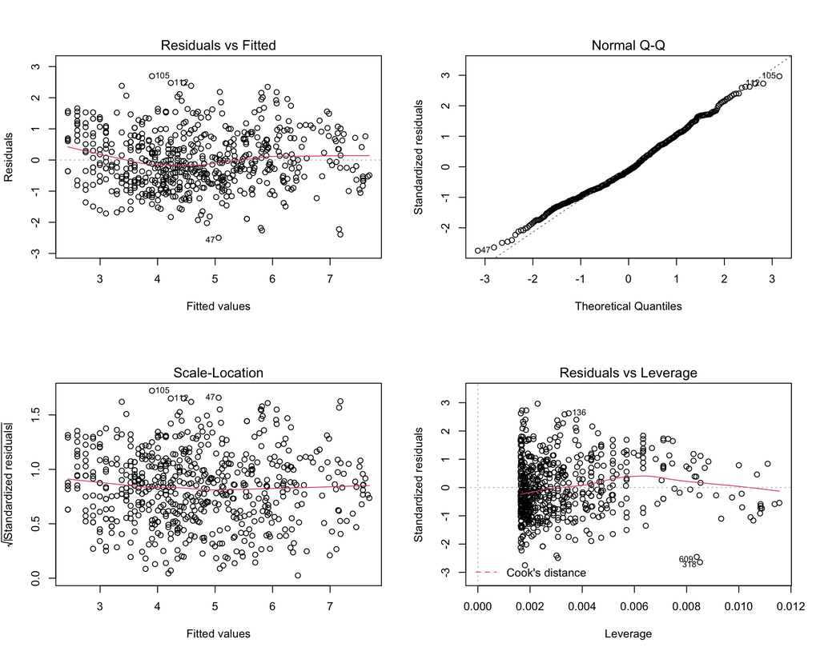

```r
par(mfrow=c(2,2))
plot(trop.fit)
```

Finally, we plot the data along with the fitted regression line, and estimated regression equation.

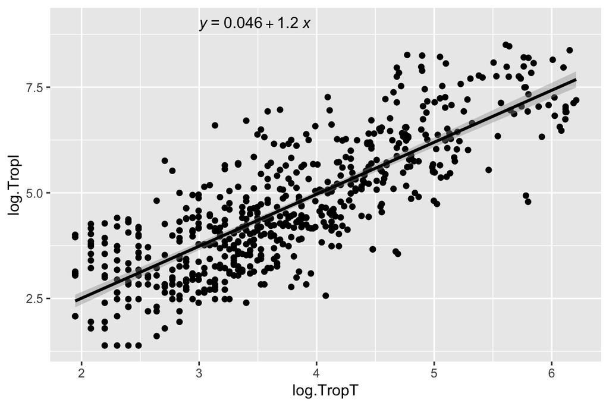

```r
library(ggplot2)
library(ggpubr)

ggplot(data_LOD_subset2, aes(x = log.TropT, y = log.TropI))+ geom_point() +
  geom_smooth(method="lm", col="black") +
  stat_regline_equation(label.x = 3, label.y = 9)
```

# 3 Analysis of predicted values

We compute the predicted log troponin I in our dataset. From this prediction, we can further calculate what will be the difference in the linear predictor of our risk score from using the predicted values rather than the observed ones.

```r
# Compute predicted log troponin I:
pred_logI <- predict.lm(trop.fit, data_LOD_subset2)

# Difference in linear predictor
dif_LP <- 0.11030707*(data_LOD_subset2$log.TropI - pred_logI)
```

We produce a scatter plot of the observed log troponin I vs the differences computed above.

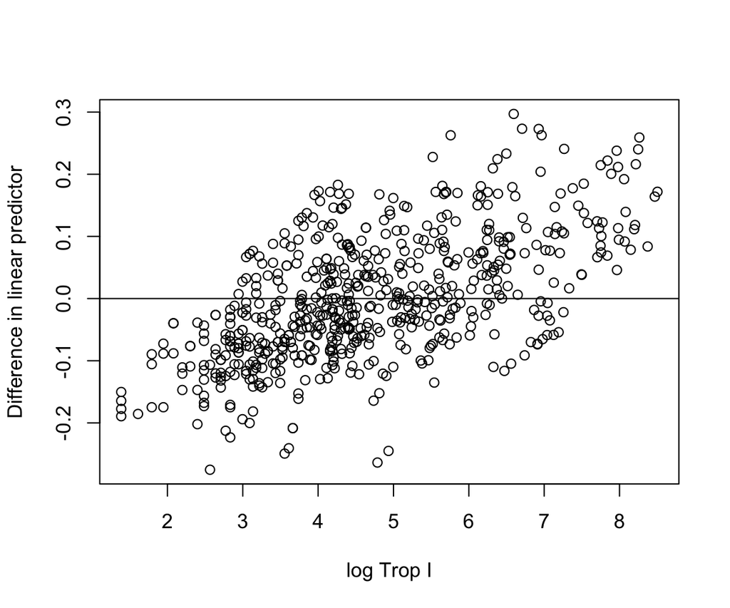

```r
plot(data_LOD_subset2$log.TropI, dif_LP,
     xlab="log Trop I", ylab = "Difference in linear predictor" )
abline(h = 0)
```

# References

“ARCHITECT Stat High Sensitivity Troponin-I.” https://www.accessdata.fda.gov/cdrh_docs/pdf19/K191595.pdf.